# Intro Statistics & Inference

2024-02-14

# Class 9: Starting Into Statistics and Inference

[output not shown]

[output not shown]

**location/central tendency:** mean, median, mode, harmonic/geometric mean **spread:** mean deviation, mean squared deviation (variance), standard deviation

## Spread

population variance = a parameter sample variance = a statistic

#### Create a function to Calculate population variance

```r
pvar <- function(x) {
  var <- sum((x-mean(x))^2)/length(x)
  r <- list(vector = x, variance = var)
  return(r) # good practice to explicitly name return variable
}

a <- c(1:10)

pvar(a)
```

```
## $vector
##  [1]  1  2  3  4  5  6  7  8  9 10
##
## $variance
## [1] 8.25
```

#### Create a function to calculate sample variance

Note: Base R function var() returns same value

```r
svar <- function(x) {
  var <- sum((x-mean(x))^2)/(length(x) -1)
  return(var)
}

svar(a)
```

```
## [1] 9.166667
```

Note: Sample variance will always be larger than population variance

Classical/frequentist statistical inference - some statistics associated with well-defined mathematical distributions (e.g., normal distribution) Some statistics are estimates of parameters of distributions

#### Draw & sample from some mathematiccal distributions and see how statistics we calculate compare to parameters of the distributions

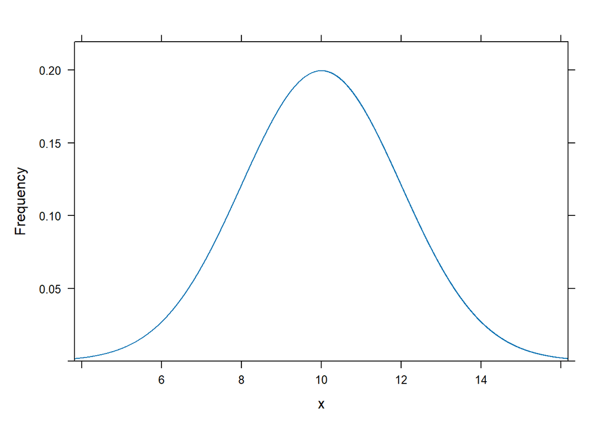

```r
mu <- 10 # center of Gaussian distribution
sigma <- 2 # standard dev. of Gaussian distribution
plotDist("norm", mean = mu, sd = sigma, xlab = "x", ylab = "Frequency")
```

#### Draw a sample out of normal distribution, look at statistics that define sample

```r
s <- rnorm(n = 10, mean = 10, sd = 2) # rnorm selects random random observation from simulated normal distribution
mean(s)
```

```
## [1] 8.774663
```

```r
sd(s)
```

```
## [1] 1.96887
```

```r
s2 <- rnorm(n = 1000, mean = 10, sd = 2) # increasing n brings sd closer to mean
mean(s2)
```

```
## [1] 10.04235
```

```r
sd(s2)
```

```
## [1] 2.057668
```

**Sampling distribution:** Set of possible statistics that could have been generated if the data collection process is repeated many times, along with the probabilities of these possible values A large enough sample of summary statistics will create a distribution itself, approaches normal distribution shape as sample size grows

#### Create sampling distribution for the mean of sample drawn from normal dstribution with mean of 10 and sd of 2

Generate a sampling distribution for the mean of sample:

```r
reps <- 500
samp_dist_mean <-
  do(reps) * mean(rnorm(n = 10, mean = 10, sd = 2))
str(samp_dist_mean)
```

```
## Classes 'do.data.frame' and 'data.frame':    500 obs. of  1 variable:
##  $ mean: num  10.3 10.6 10.1 10.4 10.9 ...
##  - attr(*, "lazy")= language ~mean(rnorm(n = 10, mean = 10, sd = 2))
##   ..- attr(*, ".Environment")=<environment: R_GlobalEnv>
##  - attr(*, "culler")=function (object, ...)
```

Generate a sampling distribution for the median of sample:

```r
samp_dist_median <-
  do(reps) * median(rnorm(n = 10, mean = 10, sd = 2))
```

#### Plots of Sampling Distributions

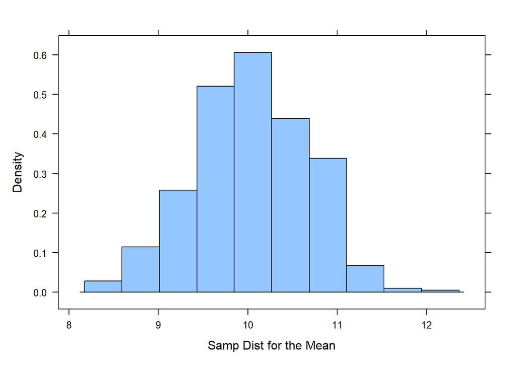

```r
histogram(~ mean, data = samp_dist_mean, xlab = "Samp Dist for the Mean")
```

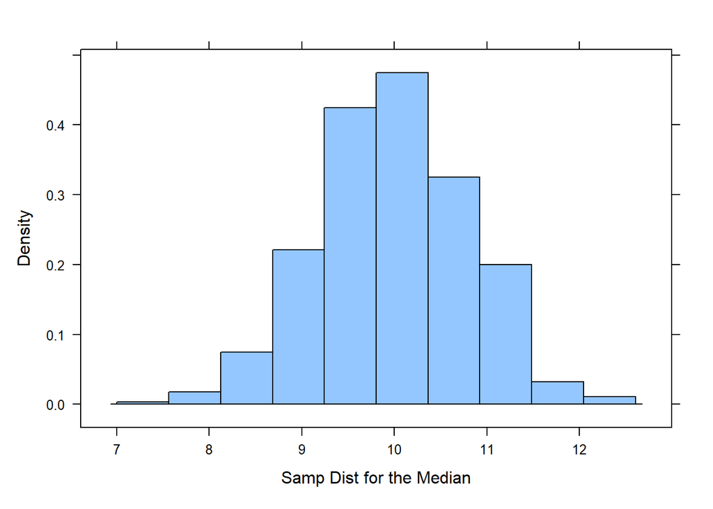

```r
histogram(~median, data = samp_dist_median, xlab = "Samp Dist for the Median")
```

The mean of a sampling distribution for a particular statistic should be a really good **point estimate** of the population value for that statistic (i.e., for mu)

```r
mean(samp_dist_mean$mean)
```

```
## [1] 10.04159
```

#### Standard Error

**Standard error** is one measure of how far off a statistic that we calculate based on a sampling distribution is likely to be from the true population value of the parameter of interest

SE = square root of the variance of the sampling distribution = standard deviation of a sampling distribution

Note: more repetitions, narrower SD will become

```r
se_mean <- sd(samp_dist_mean$mean)
se_median <- sd(samp_dist_median$median)
se_mean
```

```
## [1] 0.6298604
```

```r
se_median
```

```
## [1] 0.8097304
```

What happens to spread of sampling distribution and thus to the SE as size of samples increases?

A: Mean of sampling distribution becomes closer to population mean

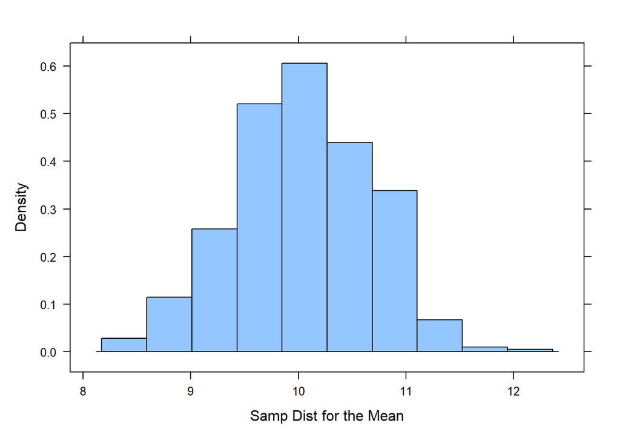

```r
samp_dist_mean2 <-
  do(reps) * mean(rnorm(n = 1000, mean = 10, sd = 2))

histogram(~ mean, data = samp_dist_mean, xlab = "Samp Dist for the Mean")
```

```r
se_mean2 <- sd(samp_dist_mean2$mean)
```

#### Confidence Intervals

Another way of describing a statistic’s sampling distribution - plays a central role in basic inferential statistics Want to know if two observations could have been drawn from the sample underlying distribution, or are they sufficiently different?

**Confidence intervals** give us a range or values into which subsequent estimates of a statistic would be expected to fall some critical proportion of the time, if the sampling exercise were to be repeated

Higher confidence = wider interval (95% CI around a statistic describes the range of values into which a new estimate of the statistic, derived from a subsequent sample. would be expected to fall 95% of the time)

CI = point estimate +/- critical value * SE Critical value depends on type of distribution (e.g., in a normal distribution, 95% of observations fall within 2 standard deviations of the mean)